# Ejercicio 1: patrones de apostadores en línea (PCA + clustering)

SESIÓN 19 — APRENDIZAJE NO SUPERVISADO

Autor/a

Jorge Juvenal Campos Ferreira — TC2001B.601

Fecha de publicación

28 de mayo de 2026

```r
options(scipen = 999)
```

## Idea central

En el aprendizaje **NO supervisado** NO hay variable objetivo (no existe una “y” que predecir). Por eso aquí **no** partimos los datos en entrenamiento/prueba: no hay un acierto que medir. El objetivo es **descubrir estructura**.

**Caso:** una plataforma de apuestas en línea quiere entender el comportamiento de sus 500 cuentas para diseñar mensajes de **juego responsable**. Nadie etiquetó a los jugadores. ¿Existen perfiles naturales de apostadores? ¿Cuántos hay y cuál concentra las señales de riesgo? *(Datos ficticios.)*

Usaremos dos familias de técnicas, todo dentro del ecosistema **tidymodels**:

- **PCA** (componentes principales): reduce las 12 variables a unos pocos ejes que concentran la varianza; sirve para visualizar y ver qué variables “van juntas”. Lo hacemos con `recipes::step_pca()`.
- **Clustering** (k-means y jerárquico): agrupa cuentas por cercanía. Lo hacemos con `tidyclust`.

```r
library(tidyverse)
library(tidymodels)
library(tidyclust)
tidymodels_prefer()
```

## 1. Carga y exploración

```r
apostadores <- read_csv("datos.csv")
glimpse(apostadores)
```

```
Rows: 500
Columns: 13
$ jugador_id                  <chr> "JUG0392", "JUG0059", "JUG0090", "JUG0268"…
$ sesiones_semana             <dbl> 18, 2, 4, 8, 15, 11, 7, 4, 4, 2, 9, 0, 3, …
$ duracion_sesion_min         <dbl> 102, 15, 14, 42, 98, 116, 29, 57, 48, 21, …
$ velocidad_apuestas_min      <dbl> 15.8, 1.7, 2.7, 6.1, 10.1, 17.0, 6.2, 5.6,…
$ num_juegos_distintos        <dbl> 3, 2, 2, 8, 4, 5, 5, 5, 6, 2, 3, 3, 2, 2, …
$ apuesta_promedio_mxn        <dbl> 168, 15, 34, 114, 273, 372, 106, 135, 110,…
$ num_depositos_mes           <dbl> 7, 0, 1, 3, 11, 9, 3, 2, 1, 2, 7, 2, 1, 1,…
$ pct_juego_madrugada         <dbl> 46.5, 0.9, 2.7, 13.5, 28.7, 35.9, 11.7, 9.…
$ pct_incremento_tras_perdida <dbl> 23.8, 0.0, 2.8, 11.2, 43.6, 53.8, 6.6, 9.3…
$ retiros_mes                 <dbl> 0.9, 1.2, 1.5, 1.4, 0.0, 0.0, 4.1, 4.6, 2.…
$ ratio_perdida_pct           <dbl> 77.5, 24.6, 24.6, 46.1, 66.9, 78.7, 73.7, …
$ dias_desde_registro         <dbl> 158, 483, 543, 824, 439, 274, 1061, 950, 2…
$ deposito_mensual_mxn        <dbl> NA, 140, 0, 355, 2892, 3459, 533, 299, 293…
```

`jugador_id` es un **identificador**, no un indicador de comportamiento: lo excluiremos del modelo (no tiene sentido medir distancias entre folios). Revisamos faltantes —los algoritmos de distancia y el PCA **no toleran NAs**—:

```r
colSums(is.na(apostadores))
```

```
                 jugador_id             sesiones_semana
                          0                           0
        duracion_sesion_min      velocidad_apuestas_min
                          0                           0
       num_juegos_distintos        apuesta_promedio_mxn
                          0                           0
          num_depositos_mes         pct_juego_madrugada
                          0                           0
pct_incremento_tras_perdida                 retiros_mes
                          0                           0
          ratio_perdida_pct         dias_desde_registro
                          0                           0
       deposito_mensual_mxn
                         15
```

**Colinealidad.** `deposito_mensual_mxn` se construye a partir de la apuesta promedio y del número de depósitos, así que esperamos correlación alta. No la eliminamos: el PCA la absorbe al proyectar sobre ejes ortogonales.

```r
apostadores %>%
  select(where(is.numeric)) %>%
  drop_na() %>%
  cor() %>%
  round(2) %>%
  .[, c("apuesta_promedio_mxn", "num_depositos_mes", "deposito_mensual_mxn")]
```

```
                            apuesta_promedio_mxn num_depositos_mes
sesiones_semana                             0.13              0.73
duracion_sesion_min                         0.31              0.76
velocidad_apuestas_min                      0.31              0.77
num_juegos_distintos                        0.14              0.31
apuesta_promedio_mxn                        1.00              0.24
num_depositos_mes                           0.24              1.00
pct_juego_madrugada                         0.07              0.78
pct_incremento_tras_perdida                 0.16              0.81
retiros_mes                                 0.17             -0.21
ratio_perdida_pct                           0.25              0.68
dias_desde_registro                         0.52             -0.16
deposito_mensual_mxn                        0.88              0.50
                            deposito_mensual_mxn
sesiones_semana                             0.29
duracion_sesion_min                         0.45
velocidad_apuestas_min                      0.45
num_juegos_distintos                        0.14
apuesta_promedio_mxn                        0.88
num_depositos_mes                           0.50
pct_juego_madrugada                         0.25
pct_incremento_tras_perdida                 0.34
retiros_mes                                 0.04
ratio_perdida_pct                           0.37
dias_desde_registro                         0.36
deposito_mensual_mxn                        1.00
```

> **¿Por qué normalizar (z-score) es indispensable?** Las variables viven en escalas muy distintas: porcentajes (0–100), conteos (0–20) y pesos (cientos a miles). Tanto el PCA (maximiza varianza) como el clustering (mide distancias) son **sensibles a la escala**. Sin normalizar, los montos en pesos dominarían todo y los grupos reflejarían las **unidades**, no el comportamiento. El z-score deja cada variable con media 0 y desviación 1: todas pesan igual.

## 2. Receta de preprocesamiento

Una sola `recipe()` resume el preprocesamiento y la reutilizamos para PCA y clustering: marcamos el id, imputamos NAs con la mediana y normalizamos.

```r
receta <- recipe(~ ., data = apostadores) %>%
  update_role(jugador_id, new_role = "id") %>%
  step_impute_median(all_numeric_predictors()) %>%
  step_normalize(all_numeric_predictors())
```

`prep()` **aprende** las medianas y los parámetros de escala; `bake()` los **aplica**. Verificamos que cada indicador quedó con media ≈ 0 y desviación ≈ 1:

```r
datos_norm <- receta %>% prep() %>% bake(new_data = NULL)
datos_norm %>%
  select(where(is.numeric)) %>%
  summarise(across(everything(), list(media = mean, desv = sd))) %>%
  glimpse()
```

```
Rows: 1
Columns: 24
$ sesiones_semana_media             <dbl> -0.0000000000000000308642
$ sesiones_semana_desv              <dbl> 1
$ duracion_sesion_min_media         <dbl> 0.00000000000000009425793
$ duracion_sesion_min_desv          <dbl> 1
$ velocidad_apuestas_min_media      <dbl> -0.0000000000000002823297
$ velocidad_apuestas_min_desv       <dbl> 1
$ num_juegos_distintos_media        <dbl> -0.000000000000000004440892
$ num_juegos_distintos_desv         <dbl> 1
$ apuesta_promedio_mxn_media        <dbl> 0.000000000000000007549517
$ apuesta_promedio_mxn_desv         <dbl> 1
$ num_depositos_mes_media           <dbl> -0.00000000000000009592327
$ num_depositos_mes_desv            <dbl> 1
$ pct_juego_madrugada_media         <dbl> 0.0000000000000001713074
$ pct_juego_madrugada_desv          <dbl> 1
$ pct_incremento_tras_perdida_media <dbl> 0.0000000000000008459899
$ pct_incremento_tras_perdida_desv  <dbl> 1
$ retiros_mes_media                 <dbl> -0.0000000000000001625367
$ retiros_mes_desv                  <dbl> 1
$ ratio_perdida_pct_media           <dbl> -0.00000000000000278022
$ ratio_perdida_pct_desv            <dbl> 1
$ dias_desde_registro_media         <dbl> -0.00000000000000003996803
$ dias_desde_registro_desv          <dbl> 1
$ deposito_mensual_mxn_media        <dbl> 0.00000000000000004174439
$ deposito_mensual_mxn_desv         <dbl> 1
```

## 3. PCA — Análisis de componentes principales

En tidymodels el PCA es **un paso más** de la receta: `step_pca()`.

```r
receta_pca <- recipe(~ ., data = apostadores) %>%
  update_role(jugador_id, new_role = "id") %>%
  step_impute_median(all_numeric_predictors()) %>%
  step_normalize(all_numeric_predictors()) %>%
  step_pca(all_numeric_predictors(), num_comp = 11, id = "pca")

pca_prep <- prep(receta_pca)
```

### 3a. Varianza explicada (scree plot)

`tidy(type = "variance")` da la varianza por componente. Buscamos el **codo**: a partir de qué componente añadir más aporta poco.

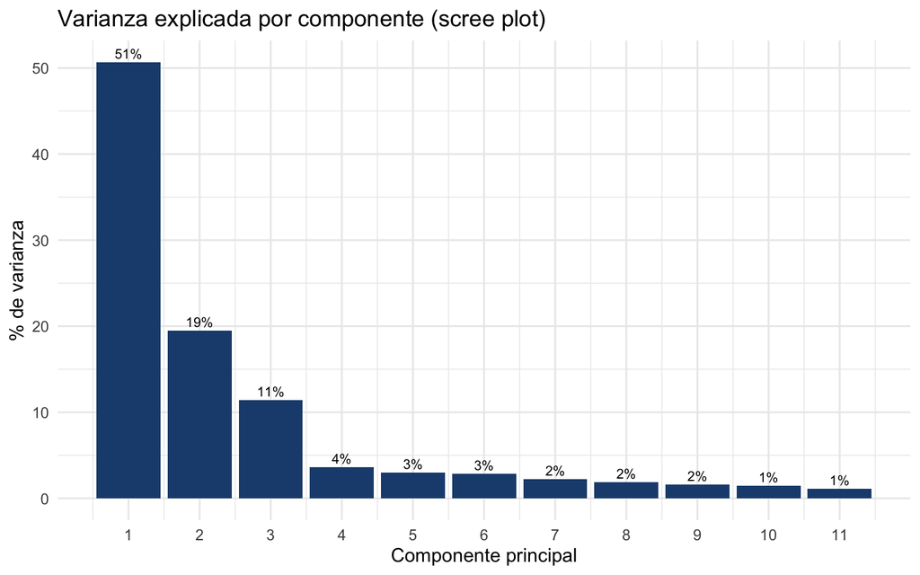

```r
varianza <- tidy(pca_prep, id = "pca", type = "variance") %>%
  filter(terms %in% c("percent variance", "cumulative percent variance")) %>%
  mutate(terms = recode(terms,
                        "percent variance" = "individual",
                        "cumulative percent variance" = "acumulada"))

varianza %>%
  filter(terms == "individual", component <= 11) %>%
  ggplot(aes(component, value)) +
  geom_col(fill = "#1e4c7d") +
  geom_text(aes(label = paste0(round(value), "%")), vjust = -0.4, size = 3) +
  scale_x_continuous(breaks = 1:11) +
  labs(title = "Varianza explicada por componente (scree plot)",
       x = "Componente principal", y = "% de varianza") +
  theme_minimal(base_size = 12)
```

### 3b. Cargas (loadings)

`tidy(type = "coef")` da el peso de cada variable en cada componente: leerlas nos dice **qué significa** cada eje. Barras grandes (en valor absoluto) definen el eje; el signo indica la dirección.

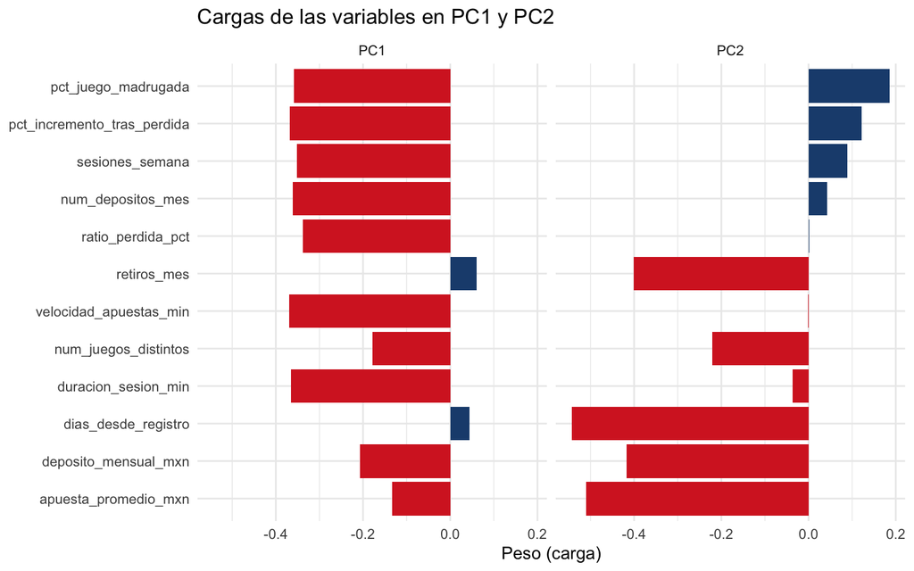

```r
cargas <- tidy(pca_prep, id = "pca", type = "coef") %>%
  filter(component %in% c("PC1", "PC2"))

cargas %>%
  mutate(terms = fct_reorder(terms, value)) %>%
  ggplot(aes(value, terms, fill = value > 0)) +
  geom_col(show.legend = FALSE) +
  facet_wrap(~ component) +
  scale_fill_manual(values = c(`TRUE` = "#1e4c7d", `FALSE` = "#d62828")) +
  labs(title = "Cargas de las variables en PC1 y PC2",
       x = "Peso (carga)", y = NULL) +
  theme_minimal(base_size = 11)
```

### 3c. Proyección de las cuentas en PC1-PC2

`bake()` sobre la receta con PCA devuelve las coordenadas (*scores*) de cada cuenta. (Las nombra `PC01, PC02, …`; renombramos las dos primeras.)

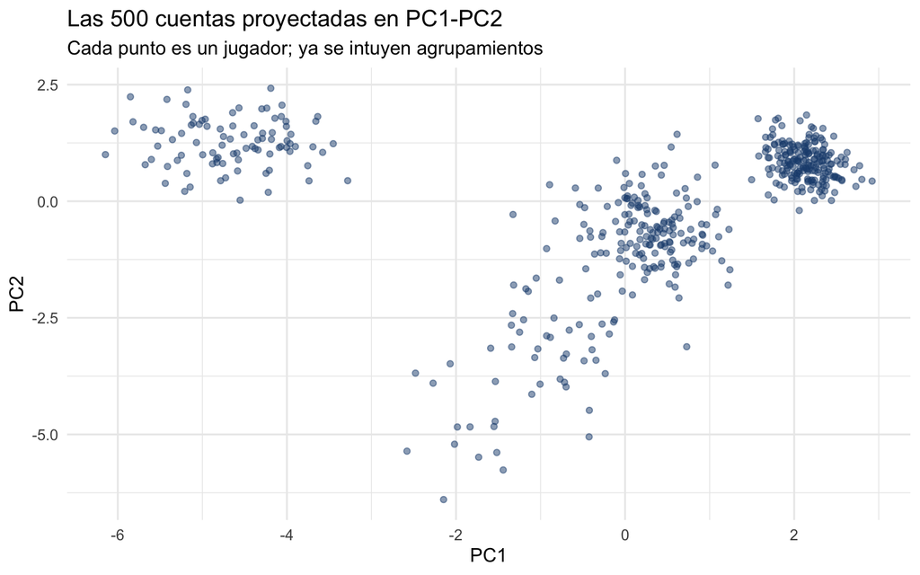

```r
scores <- bake(pca_prep, new_data = NULL) %>%
  rename(PC1 = PC01, PC2 = PC02)

scores %>%
  ggplot(aes(PC1, PC2)) +
  geom_point(alpha = 0.5, color = "#1e4c7d") +
  labs(title = "Las 500 cuentas proyectadas en PC1-PC2",
       subtitle = "Cada punto es un jugador; ya se intuyen agrupamientos") +
  theme_minimal(base_size = 12)
```

## 4. ¿Cuántos grupos? Elección de k con `tune_cluster()`

k-means necesita que fijemos *k* de antemano. Declaramos el modelo con `num_clusters = tune()` y dejamos que `tune_cluster()` pruebe varios valores, midiendo dos diagnósticos: `sse_within_total` (para el **codo**) y `silhouette_avg` (cuanto **más alta**, mejor).

```r
receta_clust <- recipe(~ ., data = apostadores) %>%
  update_role(jugador_id, new_role = "id") %>%
  step_impute_median(all_numeric_predictors()) %>%
  step_normalize(all_numeric_predictors())

km_spec <- k_means(num_clusters = tune()) %>%
  set_engine("stats", nstart = 25)   # 25 arranques: evita óptimos locales

wf_km <- workflow() %>%
  add_recipe(receta_clust) %>%
  add_model(km_spec)

metricas_clust <- cluster_metric_set(sse_within_total, silhouette_avg)

rejilla_k <- tibble(num_clusters = 1:8)
set.seed(123)
folds <- vfold_cv(apostadores, v = 5)

set.seed(123)
afinado <- tune_cluster(wf_km, resamples = folds,
                        grid = rejilla_k, metrics = metricas_clust)

metricas_k <- collect_metrics(afinado)
metricas_k
```

```
# A tibble: 16 × 7
   num_clusters .metric          .estimator     mean     n   std_err .config
          <int> <chr>            <chr>         <dbl> <int>     <dbl> <chr>
 1            1 silhouette_avg   standard    NaN         0 NA        Preprocess…
 2            1 sse_within_total standard   4788         5  1.20e-12 Preprocess…
 3            2 silhouette_avg   standard      0.500     5  1.55e- 3 Preprocess…
 4            2 sse_within_total standard   2745.        5  9.07e+ 0 Preprocess…
 5            3 silhouette_avg   standard      0.411     5  1.70e- 3 Preprocess…
 6            3 sse_within_total standard   1836.        5  7.49e+ 0 Preprocess…
 7            4 silhouette_avg   standard      0.453     5  1.25e- 3 Preprocess…
 8            4 sse_within_total standard   1253.        5  4.61e+ 0 Preprocess…
 9            5 silhouette_avg   standard      0.432     5  1.30e- 2 Preprocess…
10            5 sse_within_total standard   1171.        5  4.78e+ 0 Preprocess…
11            6 silhouette_avg   standard      0.367     5  3.75e- 3 Preprocess…
12            6 sse_within_total standard   1107.        5  7.65e+ 0 Preprocess…
13            7 silhouette_avg   standard      0.356     5  2.31e- 3 Preprocess…
14            7 sse_within_total standard   1060.        5  6.89e+ 0 Preprocess…
15            8 silhouette_avg   standard      0.248     5  2.92e- 2 Preprocess…
16            8 sse_within_total standard   1021.        5  4.67e+ 0 Preprocess…
```

**Método del codo:**

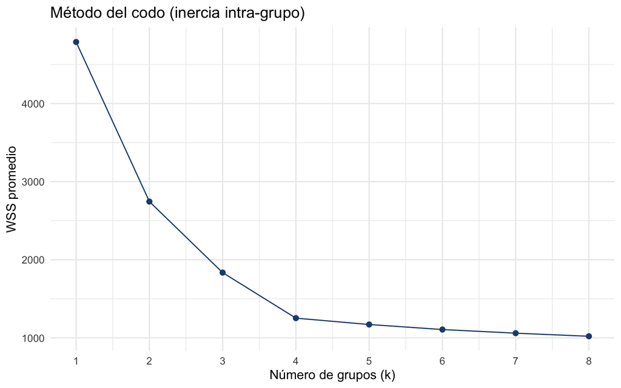

```r
metricas_k %>%
  filter(.metric == "sse_within_total") %>%
  ggplot(aes(num_clusters, mean)) +
  geom_line(color = "#1e4c7d") +
  geom_point(size = 2, color = "#1e4c7d") +
  scale_x_continuous(breaks = 1:8) +
  labs(title = "Método del codo (inercia intra-grupo)",
       x = "Número de grupos (k)", y = "WSS promedio") +
  theme_minimal(base_size = 12)
```

**Método de la silueta** (no se define para k = 1):

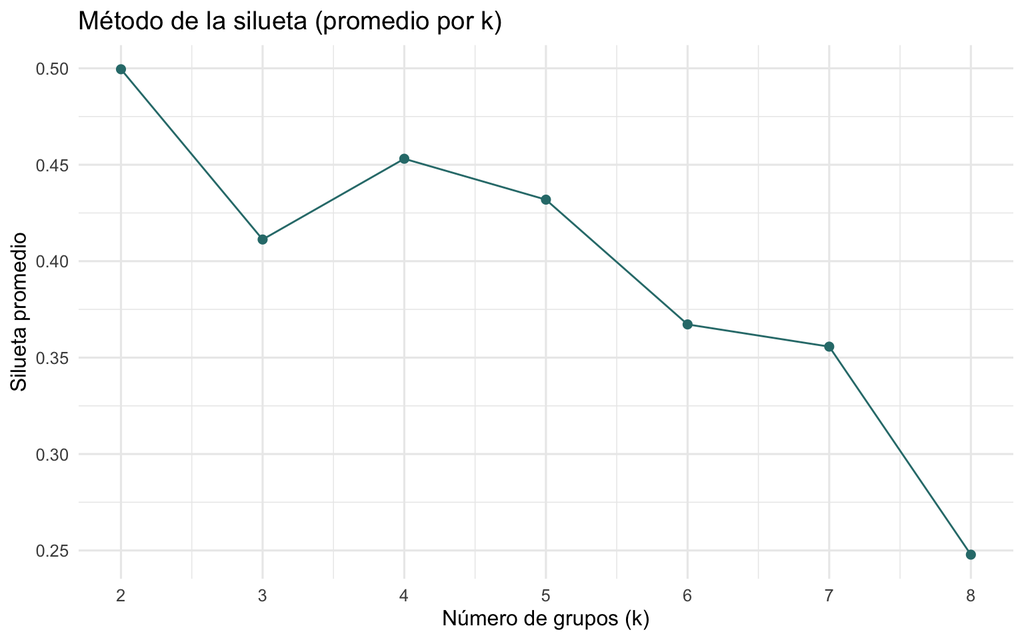

```r
metricas_k %>%
  filter(.metric == "silhouette_avg", num_clusters >= 2) %>%
  ggplot(aes(num_clusters, mean)) +
  geom_line(color = "#2d7a7a") +
  geom_point(size = 2, color = "#2d7a7a") +
  scale_x_continuous(breaks = 2:8) +
  labs(title = "Método de la silueta (promedio por k)",
       x = "Número de grupos (k)", y = "Silueta promedio") +
  theme_minimal(base_size = 12)
```

> **Un caso realista donde los diagnósticos no coinciden.** La silueta es más alta en k = 2 (la división más “limpia”: intensos vs. ligeros). Pero el codo sigue bajando de forma importante hasta k = 4 y luego se aplana: hay estructura más fina. Los diagnósticos son **guías**, no veredictos. Como el objetivo es accionable (mensajes para perfiles distinguibles), elegimos **k = 4**: grupos interpretables y separados.

```r
k_elegido <- 4
```

## 5. K-means final

```r
km_final <- k_means(num_clusters = k_elegido) %>%
  set_engine("stats", nstart = 25)
wf_final <- workflow() %>% add_recipe(receta_clust) %>% add_model(km_final)

set.seed(123)
ajuste_km <- fit(wf_final, data = apostadores)

asignacion <- extract_cluster_assignment(ajuste_km)
table(asignacion$.cluster)
```

```
Cluster_1 Cluster_2 Cluster_3 Cluster_4
       90       206       148        56
```

Centroides en el espacio **normalizado** (positivo = por encima del promedio):

```r
extract_centroids(ajuste_km)
```

```
# A tibble: 4 × 13
  .cluster  sesiones_semana duracion_sesion_min velocidad_apuestas_min
  <fct>               <dbl>               <dbl>                  <dbl>
1 Cluster_1          1.74                1.64                    1.73
2 Cluster_2         -0.741              -0.843                  -0.775
3 Cluster_3          0.0483              0.0229                 -0.130
4 Cluster_4         -0.191               0.411                   0.408
# ℹ 9 more variables: num_juegos_distintos <dbl>, apuesta_promedio_mxn <dbl>,
#   num_depositos_mes <dbl>, pct_juego_madrugada <dbl>,
#   pct_incremento_tras_perdida <dbl>, retiros_mes <dbl>,
#   ratio_perdida_pct <dbl>, dias_desde_registro <dbl>,
#   deposito_mensual_mxn <dbl>
```

### 5a. Los grupos sobre PC1-PC2

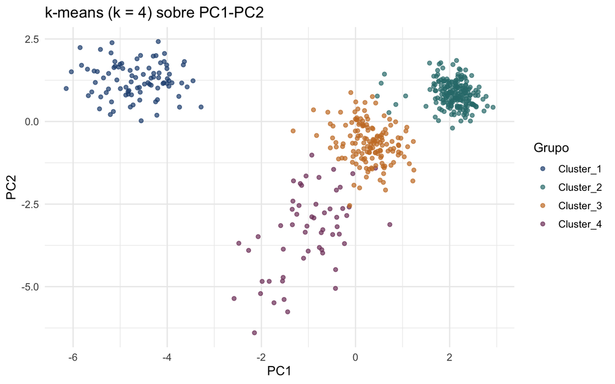

```r
scores_grupos <- scores %>% bind_cols(cluster = asignacion$.cluster)

scores_grupos %>%
  ggplot(aes(PC1, PC2, color = cluster)) +
  geom_point(alpha = 0.7) +
  scale_color_manual(values = c("#1e4c7d", "#2d7a7a", "#c97b2a", "#7d3c66")) +
  labs(title = paste0("k-means (k = ", k_elegido, ") sobre PC1-PC2"),
       color = "Grupo") +
  theme_minimal(base_size = 12)
```

### 5b. Perfilado en unidades originales

Para interpretar **qué tipo de jugador** es cada grupo, promediamos las variables originales (no las normalizadas) por cluster.

```r
apostadores_grupos <- apostadores %>% bind_cols(cluster = asignacion$.cluster)

perfil <- apostadores_grupos %>%
  group_by(cluster) %>%
  summarise(
    n = n(),
    sesiones_semana = mean(sesiones_semana),
    apuesta_promedio_mxn = mean(apuesta_promedio_mxn),
    deposito_mensual_mxn = mean(deposito_mensual_mxn, na.rm = TRUE),
    pct_juego_madrugada = mean(pct_juego_madrugada),
    pct_incremento_tras_perdida = mean(pct_incremento_tras_perdida),
    retiros_mes = mean(retiros_mes),
    ratio_perdida_pct = mean(ratio_perdida_pct)
  ) %>%
  mutate(across(where(is.numeric), ~ round(.x, 1)))
perfil
```

```
# A tibble: 4 × 9
  cluster       n sesiones_semana apuesta_promedio_mxn deposito_mensual_mxn
  <fct>     <dbl>           <dbl>                <dbl>                <dbl>
1 Cluster_1    90            11.8                 253.                2116
2 Cluster_2   206             2.1                  41                  126.
3 Cluster_3   148             5.2                 132.                 403.
4 Cluster_4    56             4.2                1306.                5433.
# ℹ 4 more variables: pct_juego_madrugada <dbl>,
#   pct_incremento_tras_perdida <dbl>, retiros_mes <dbl>,
#   ratio_perdida_pct <dbl>
```

**Interpretación (leyendo `perfil` y los centroides).** Cada grupo corresponde a un perfil con sentido: *recreativo ocasional* (pocas sesiones, montos bajos, casi nada de madrugada ni *chasing*); *entusiasta controlado* (juega seguido y variado, pero retira y no persigue); *en riesgo / problemático* (muchas sesiones, alto % de madrugada, persigue pérdidas, casi no retira → objetivo de juego responsable); y *gran apostador* (montos enormes pero controlado). El alumno debe **nombrar** cada grupo con las cifras reales observadas.

## 6. Clustering jerárquico (comparación)

El jerárquico no fija *k* de antemano: fusiona puntos por cercanía y luego “cortamos”. En tidyclust se usa igual, con `hier_clust()`.

```r
hc_spec <- hier_clust(num_clusters = k_elegido,
                      linkage_method = "ward.D2") %>%
  set_engine("stats")

wf_hc <- workflow() %>% add_recipe(receta_clust) %>% add_model(hc_spec)
ajuste_hc <- fit(wf_hc, data = apostadores)
asignacion_hc <- extract_cluster_assignment(ajuste_hc)

table(kmeans = asignacion$.cluster, jerarquico = asignacion_hc$.cluster)
```

```
           jerarquico
kmeans      Cluster_1 Cluster_2 Cluster_3 Cluster_4
  Cluster_1        90         0         0         0
  Cluster_2         0       204         2         0
  Cluster_3         0         0       147         1
  Cluster_4         0         0         0        56
```

Las etiquetas de grupo son **arbitrarias** (el “Cluster_1” de un método no es el del otro). No miramos la diagonal, sino si cada grupo de un método cae mayormente en **un solo** grupo del otro: eso indica que ambos descubren la **misma estructura**, lo que da confianza en los perfiles encontrados.